# Provider Dashboard Tip Sheet

Published

August 30, 2022

**Reporting Links.**

Green blocks indicate direct links to reports.

**Informational Resources**

Blue blocks highlight important information or resources.

# **Overview**

The dashboard offers a comprehensive view of several different quality measures such as:

- Visits per Half Day
- UDS Composite Score
- Patient Satisfaction Surveys Score
- Continuity of Care Score

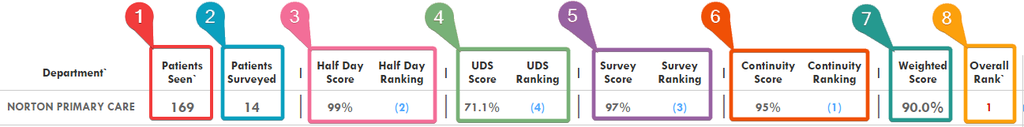

# **1 - Patients Seen**

The $\#$ of patients seen, or in other words, the $\#$ of completed billable patient encounters.

**Medical Directors Only**

[Visit Statistics Dashboard](https://sachstbl01/views/PatientVisitsDashboard/VisitStatistics?:origin=card_share_link&:embed=n).

**Providers**

At this time providers do not have access to the **Visit Statistics Dashboard**.

# **2 - Patients Surveyed**

The $\#$ of patients who have completed a survey after their visit.

For more information please see section [*5 - Patient Satisfaction Surveys*](http://localhost:5261/#patient-satisfaction-surveys)

# **3 - Half Day**

**Medical Directors & Indivual Providers**

[Provider Half-Day Dashboard](https://sachstbl01/views/HalfDayProviderDashboard/ProviderReport?:origin=card_share_link&:embed=n).

**Update Frequency**

The report is typically updated the $2nd$ week of every month for the prior months data.

# **4 - UDS Composite Score**

Family Medicine `\` Internal Medicine serves different patient populations compared to Pediatrics. Thus, it is appropriate to use quality measures that apply to these respective departments.

The quality measures are then aggregated into a single composite score.

### **Family Medicine & Internal Medicine Measures**

| $1.$ Breast Cancer Screening | $7.$ HIV Screening |
| --- | --- |
| $2.$ Cervical Cancer Screening | $8$ Statin Therapy |
| $3.$ Colo-rectal Cancer Screening | $9.$ Tobacco Screening & Cessation |
| $4.$ Controlling High Blood Pressure | $10.$ Use of Aspirin of Anti platelet |
| $5.$ Depression Screening | $11.$ Weight Assessment & Counseling |
| $6.$ Diabetes: Hemoglobin A1c |  |

### **Pediatric Measures**

| $1.$ Childhood Immunizations | $3.$ Depression Screening & Follow Up |
| --- | --- |
| $2.$ Depression Remission | $4.$ Weight Assessment & Counseling |

**Medical Directors & Indivual Providers**

[UDS Report](https://sachstbl01/views/HalfDayProviderDashboard/ProviderReport?:origin=card_share_link&:embed=n).

# **5 - Patient Satisfaction Surveys**

Patient satisfaction surveys consist of a total of $14$ questions, however not all of these questions are directly provider related, so questions are split into two groups:

| Group | $\#$ of Questions | Info |
| --- | --- | --- |
| General | $9$ | Patient overall experience, from making an appointment to interactions with staff. |
| Provider Related | $5$ | Provider to patient interaction & quality of care. |

**Medical Directors & Indivual Providers**

[Patient Satisfaction Report](https://sachstbl01/views/HalfDayProviderDashboard/ProviderReport?:origin=card_share_link&:embed=n).

**Note**

The exact survey questions are available [here](https://raw.githubusercontent.com/sachealthit/Docs/master/Survey%20Information.png)

# **6 - Continuity of Care**

Continuity is calculated as a percentage $(\%)$ from the following formula:

$$\frac{\# \space \space of \space Visits \space \space with \space \space Assigned \space \space Patients }{\# \space \space Completed \space \space Visits}= Continuity \space \space \%$$

**Medical Directors & Indivual Providers**

[Continuity Report](https://sachstbl01/views/Continuity/ProviderContinuity?:origin=card_share_link&:embed=n).

**Note**

If you have any continuity or empanelment questions contact *Sara Ruiz*.

# **7 - Weighted Score**

Each measure is assigned a weight, these weights can be found below:

| Measures | Weight |
| --- | --- |
| Half Day Score | $40\%$ |
| UDS Composite Score | $30\%$ |
| Patient Surveys Score | $20\%$ |
| Continuity of Care | $10\%$ |
| **TOTAL** | $100\%$ |

### *Weighted Score Example*

[output not shown]

# **8 - Overall Rank**

Once all weighted scores are calculated, a rank is then assigned to each provider within his or her specialty.

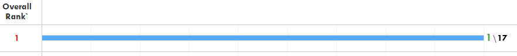

# **Dashboard Overview**

For the purposes of the demo we will be taking a look at the **Individual Provider View**, specifically Dr.Palisoc’s June 2022 data.

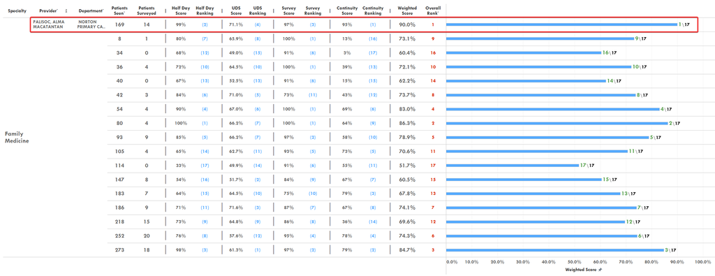

### **Ranking Within Individual Measures**

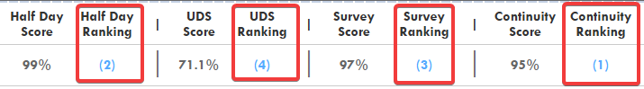

Each box represents a provider’s rank within that measure alone. For example:

| Measure | Ranking | Interpretation |
| --- | --- | --- |
| Half Day | $2$ | $2nd$ Best Half Day Score |
| UDS | $4$ | $4th$ Best UDS Composite score |

### **Drill Down Information**

To view the data behind the individual scores follow these steps:

1. Click anywhere on your row of information.
2. A pop-up menu will appear with links to each of the individual reports.

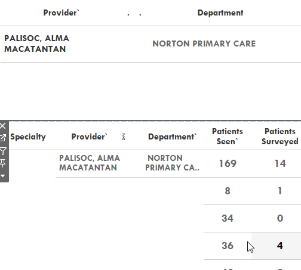

# **Accessing the Report**

In order to view the report on **Tableau** you must be on a **SAC Health** OR **Loma Linda University Health** internet connection either by being at one of the sites or via VPN.

Once logged into Tableau you can find the report with the following steps:

1. Open the **Clinical** folder.
2. Click on **Individual Provider Dashboard**.
3. Select **Individual Provider View**.

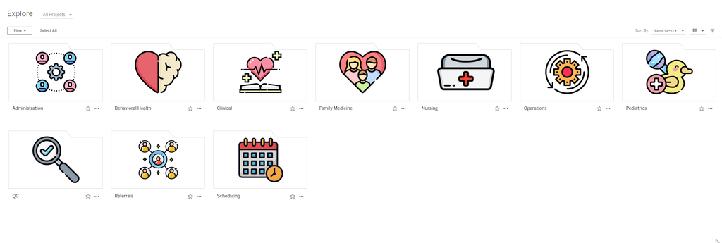

**Note**

Clicking the star symbol next to the name of the report will add it to your favorites section located on the left side of the screen.

[figure not shown]

If you experience any issues please contact Phillip Ho.

# **Feedback & Suggestions**

For more reporting resources visit our [SharePoint Site](https://sachealth.sharepoint.com/sites/ITDataAnalytics/SitePages/Home.aspx)

[figure not shown]